# Construção de indicadores de acessibilidade espacial à saúde com o pacote asha (versão inicial)

Exemplo a partir do caso da cidade de São Paulo

Bruno Pinheiro[^1]

Escola de Artes, Ciências e Humanidades da Universidade de São Paulo  
bruno.pinheiro.oliveira@usp.br

Alexandre Ribeiro Leichsenring[^2]

Escola de Artes, Ciências e Humanidades da Universidade de São Paulo  
alexandre.leichsenring@usp.br

2018-08-03

# 1 Introdução

O R tem sido uma base computacional bastante utilizada para estudos e pesquisas na área de saúde. As aplicações mais tradicionais neste campo são pacotes voltados à análise epidemiológica como `epitools`, `epi`, `epiR`, `epidisplay` (Plummer and Carstensen 2011, Stevenson et al. (2013)), entre outros. Com o crescimento de fontes de dados abertos, têm surgido também uma série de pacotes com a finalidade de viabilizar acesso a respositórios de dados em saúde como o `fingertips`, o `WHO` e o `datasus`. Ainda mais recentemente, com a popularização do *machine learning* e do *big data*, começam a surgir pacotes para aplicações de inteligência artificial em saúde como o `healthcareai`.

Um campo de estudos em saúde que vem crescendo e se beneficia fortemente dos recentes desenvolvimentos na área de computação e de disponibilidade de dados é o da acessibilidade espacial. Trata-se de uma área essencialmente interdisciplinar, de diálogo entre as ciências humanas e exatas, articulando os campos da saúde pública, do planejamento urbano e da mobilidade urbana. De tal forma, uma gama variada de abordagens podem valer-se de estudos de análise espacial, assim como é uma relevante ferramenta para melhores tomadas de decisão.

Pacotes como o `stplanr`, que permite a obtenção de dados de mobilidade, a realização de análise de origem-desstino e a construção de modelos e redes voltados ao planejamento dos transportes, são extremamente úteis para este tipo de tarefa. Ainda assim, uma das potencialidades dos pacotes feitos especificamente para certos tipos de análise é a possibilidade de replicabilidade e padronização dos métodos, como o fazem os pacotes para análises epedemiológicas citados acima. Neste sentido, há uma lacuna de pacotes no R para análise de acessibilidade espacial à saúde.

O pacote `asha` é produto do projeto de pesquisa “Mobilidade urbana e direito à cidade na cidade de São Paulo”, desenvolvido na Escola de Artes, Ciências e Humanidades da Universidade de São Paulo, no contexto da graduação em Gestão de Políticas Públicas. A investigação fundamenta-se na lógica do direito à cidade e parte do pressuposto de que a acessibilidade na cidade é composta pelo entrelaçamento de uma série de “acessibilidades temáticas”, que abrangem a educação, a saúde, o lazer, a cultura, o esporte, o trabalho e outros serviços.

Como uma primeira etapa, a pesquisa analisou a acessibilidade espacial à atenção básica de saúde no município de São Paulo, por meio de dois indicadores criados a partir de dados públicos: acessibilidade competitiva (AC) e acessibilidade viável (AV). A metodologia permite a análise de padrões de acessibilidade espacial em diferentes modelos territoriais de atenção básica, podendo ser útil para uma melhor compreensão das dinâmicas de acessibilidade estabelecidas pela infraestrutura de distribuição das capacidades de atendimento.

O pacote `asha` compila funções que viabilizam a reprodução do procedimento adotado para a modelagem, a geração e análise dos indicadores. Esta vinheta apresenta como usar o pacote a partir da metodologia e dos dados utilizados no estudo, visando contribuir para a replicabilidade deste tipo de análise.

## 1.1 O pacote `asha`

Antes de seguir, é preciso instalar o pacote asha caso ele ainda não esteja instalado. O pacote está no Github e pode ser instalado usando `devtools::install_github("bruno-pinheiro/asha")`. Apenas desmarque a linha de código abaixo para isso.

```r
# install.packages("devtools") # para o caso do devtools não estar instalado
# devtools::install_github("bruno-pinheiro/asha") # para instalar o pacote asha
```

vamos carregar os pacotes que utilizaremos

```r
library(dplyr)
library(sf)
library(ggplot2)
library(stplanr)
library(asha)
```

A proposta do pacote é auxiliar na realização computacional das seguintes tarefas envolvidas na análise da acessibilidade espacial:

1. Levantamento de dados de rota
2. Modelagem da estrutura de Origem-Destino do sistema de saúde
3. Geração de indicadores
4. Visualização dos indicadores

Dada a disponibilidade de um conjunto particular de dados, o objetivo das funções do pacote é viabilizar a realização deste fluxo.

## 1.2 Funções

Para construir os indicadores serão utilizadas as seguintes funções do pacote `asha`:

**Levantamento de dados de mobilidade**

- `asha_dists`

**Modelagem da acessibilidade espacial**

- `asha_zones`
- `asha_intersect`
- `asha_nn`

**Geração de indicadores**

- `asha_ac`
- `asha_av`

Além disso, utilizaremos as funções abaixo para visualizar rapidamente os dados.

**Visualização dos dados**

- `asha_bar`
- `asha_hist`

É possível consultar a documentação de referência de qualquer função entrando com o comando `?nome_da_funcao` ou `help(nome_da_funcao)` no console do R. Por exemplo, para visitar as referências da função `asha_ac` utiliza-se o comando`?asha_ac`.

## 1.3 Classes

Basicamente o pacote lida com duas classes de dados: data frames e objetos espaciais do tipo `sf` (*simple features*).

Para representação espacial, o R dispõe de duas linguagens principais. A mais tradicional é derivada do pacote `sp`. Mais recentemente, porém, o pacote `sf` surgiu para facilitar a análise espacial integrando este tipo de representação à estrutura de dados do `tidyverse`, de modo que é possível valer-se das funcionalidades do `dplyr`, do `ggplot2` e outros pacotes que integram a linguagem `tidy` no R.

Classes dos dados de input e ouput nas funções do pacote `asha`

| Função | Formato *input* | Formato *output* |
| --- | --- | --- |
| `asha_zones` | dois objetos `sf` | um objeto `sf` |
| `asha_intersect` | dois objetos `sf` | um `data frame` |
| `asha_nn` | dois objetos `sf` | um `data frame` |
| `asha_ac` | um `data frame` | uma coluna no `data frame` |
| `asha_av` | um `data frame` | três colunas no `data frame` |

# 2 Metodologia

A a análise e a construção dos indicadores foi feita por meio da estruturação de modelos territoriais baseados em matrizes de origem e destino (OD). Concebe-se como origem os diversos locais que representam pontos de partida da população que conforma a demanda das unidades de saúde. Estes pontos podem ser a localização das residências das pessoas ou o centroide de uma determinada área. No estudo utilizamos os centroides dos setores censitários como referência para os pontos de origem.

Já o destino é a unidade de saúde que recebe a população referente a um determinando conjunto de pontos de origem. Com foco na análise da atenção básica de saúde e sendo o estudo de corte transversal, foram as 455 Unidades Básicas de Saúde (UBS) em funcionamento na cidade de São Paulo no momento em que os dados foram coletados (setembro de 2017).

A partir desta modelagem é possível identificar dados de rotas para as conexões OD, assim como atribuir dados relativos à capacidade de atendimento para cada uma delas.

No caso desta pesquisa, os dados de rota foram usados apenas para delimitar o critério de acessibilidade viável, dada a característica do sistema de saúde, que delimita áreas de abrangência para as UBS e determina qual unidade deve ser frequentada pela população a partir do endereço residencial. Para casos onde o sistema permita sobreposição territorial da oferta, porém, é possível estabelecer territórios de acesso baseado no tempo de percurso e gerar indicadores cumulativos.

## 2.1 Dados fundamentais

Para utilizar o pacote `asha` é necessário ter em mãos um conjunto específico de bases de dados a respeito do território e dos serviços de saúde pública. Por hora o pacote não conta com funções para a obtenção direta dos dados, por isto é preciso obtê-los previamente junto às suas respectivas fontes.

As bases de dados utilizadas na análise da cidade de São Paulo já estão incorporadas ao pacote e podem servir de exemplo para os dados que deverão ser obtidos para viabilizar a análise. Para ver todos os dados disponíveis no pacote digite `data(package = "asha")` no console`.

No caso, a pesquisa baseou-se nas seguintes bases de dados:

### 2.1.1 Dados espaciais

#### 2.1.1.1 Malha de setores censitários da cidade de São Paulo

Os setores censitários são a menor unidade cadastral do censo demográfico realizado pelo IBGE a cada 10 anos. São pequenas unidades territorias contíguas que cobrem mais ou menos um quarteirão e são convergentes com os limites político-administrativos do Brasil, permitindo análises espaciais com um nível substancial de resolução espacial.

```r
setores_sp <- setores_sp %>%
  select(cd_geocodi:dens_demografica)
head(as.data.frame(setores_sp))
```

```
#>        cd_geocodi cd_geocodd nm_distrit   tipo pessoas_sp       area
#> 1 355030801000001  355030801  AGUA RASA URBANO        806 0.07213308
#> 2 355030801000002  355030801  AGUA RASA URBANO        913 0.07162393
#> 3 355030801000003  355030801  AGUA RASA URBANO        625 0.05596828
#> 4 355030801000004  355030801  AGUA RASA URBANO        572 0.06840022
#> 5 355030801000005  355030801  AGUA RASA URBANO        754 0.08228113
#> 6 355030801000006  355030801  AGUA RASA URBANO        643 0.09869561
#>   dens_demografica                       geometry
#> 1        11173.791 MULTIPOLYGON (((339822.4 73...
#> 2        12747.136 MULTIPOLYGON (((339904.3 73...
#> 3        11167.040 MULTIPOLYGON (((339920.6 73...
#> 4         8362.546 MULTIPOLYGON (((339843.1 73...
#> 5         9163.705 MULTIPOLYGON (((339539.3 73...
#> 6         6514.981 MULTIPOLYGON (((339400.5 73...
```

Cada polígono no mapa corresponde a um setor censitário. O dataset `setores_sp` é um objeto de classe `sf`, contendo a malha de setores e um conjunto de variáveis relacionadas a cada setor censitário, que na cidade de São Paulo são 18.953.

#### 2.1.1.2 Localização de estabelecimentos de saúde

É preciso ter a localização georreferenciada das unidades de saúde. Assim esta base deve ser um conjunto de pontos espaciais, cada um representando uma Unidade Básica de Saúde da cidade de São Paulo.

Esta base indica os “pontos de destino” na nossa pesquisa, isto é, os pontos que são objetivo final do percurso das pessoas entre suas residências e o provedor do serviço. No dataset `ubs_sp` cada UBS está referenciada pelo seu código no Cadastro Nacional de Estabelecimentos de Saúde (CNES).

```r
head(as.data.frame(ubs_sp))
```

```
#>      cnes                 geometry
#> 1 2751887   POINT (325958 7374738)
#> 2 2787539 POINT (320593.1 7379141)
#> 3 2751879 POINT (327002.1 7400091)
#> 4 4050312 POINT (355794.9 7394010)
#> 5 2752328 POINT (347709.4 7396163)
#> 6 2751844 POINT (332071.5 7385921)
```

Esta base de dados é fruto de uma atualização no shapefile de UBS disponibilizados no [Portal de Dados Abertos](http://dados.prefeitura.sp.gov.br/) do Município de São Paulo e também no [Portal GeoSampa](http://geosampa.prefeitura.sp.gov.br/), que envolveu cruzamento com uma base mais recente de áreas de UBS e geocodificação de endereços.

#### 2.1.1.3 Áreas de cobertura das UBS da cidade de São Paulo

Em São Paulo, cada UBS é responsável por atender a população residente num território determinado pela sua área de cobertura. Assim, além da localização exata do equipamento, a gestão da saúde tem de decidir também qual a abrangência territorial de cada UBS, criando um uma malha geográfica da atenção básica, armazenada no dataset `ubs_sp_areas`.

Embora esta base não esteja disponível para acesso via transparência ativa, foi possível obtê-la a partir de pedido de acesso à informação impetrado para a Secretaria Municipal de Saúde da Prefeitura de São Paulo.

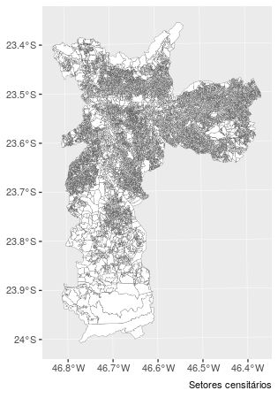

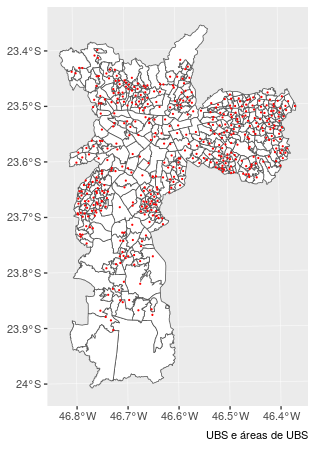

```r
p1 <- ggplot() +
  geom_sf(data = setores_sp, fill = "white", lwd = .1) +
  labs(caption = "Setores censitários")
  tema_mapa

p2 <- ggplot() +
  geom_sf(data = ubs_sp_areas, , fill = "white", lwd = .3) +
  geom_sf(data = ubs_sp, col = "red", lwd = .2) +
  labs(caption = "UBS e áreas de UBS")

do.call(gridExtra::grid.arrange, c(list(p1, p2), ncol = 2))
```

### 2.1.2 Dados tabulares

#### 2.1.2.1 Demanda por serviços de saúde

A demanda por serviços de saúde $(D)$ é quantificada a partir do número de moradores residentes nos setores censitários associados a cada unidade de saúde. Para gerar este indicador foi utilizada a variável `V002` do arquivo `Domicilio02_SP1.csv`, que consta nos resultados do universo do Censo 2010 agregados por setor censitário, também disponibilizados pelo IBGE.

```r
head(pessoas_sp)
```

```
#>        cd_geocodi pessoas_sp
#> 1 355030801000001        806
#> 2 355030801000002        913
#> 3 355030801000003        625
#> 4 355030801000004        572
#> 5 355030801000005        754
#> 6 355030801000006        643
```

O objeto pessoas_sp é a variável demográfica base do cálculo de demanda, com o número de moradores em domicílios particulares e coletivos. A soma dos habitantes de cada um dos setores censitários resulta no total de habitantes da cidade, que era de mais de 11 milhões de pessoas em 2010, conforme pode-se ver abaixo.

```r
sum(setores_sp$pessoas_sp, na.rm = TRUE)
```

```
#> [1] 11253503
```

#### 2.1.2.2 Capacidade de atendimento dos equipamentos de saúde

Estes dados devem ser relativos ao total de profissionais disponíveis para atender a demanda da unidade de saúde. No caso, a pesquisa considerou o número de medicos e enfermeiros nas UBS de São Paulo. Os foram obtidos no CNES, considerando todas as especialidades, e estão compilados em `ubs_sp_profissionais`.

```r
head(ubs_sp_profissionais)
```

```
#>      cnes total_enf total_med
#> 1 2026961         3         7
#> 2 2026988        11        25
#> 3 2026996         6        14
#> 4 2027011         4         5
#> 5 2027038         3         6
#> 6 2027046         4         5
```

Trata-se de um data frame com três colunas, que apontam o total de médicos e de enfermeiros trabalhando nas UBS em setembro de 2017. Cada UBS é identificada pelo seu código CNES. Os dados da oferta de profissionais são utilizados para contabilizar as oportunidades ($O$), entendidas como a soma de médicos e enfermeiros à disposição para atender a população residente na área de cobertura da UBS nas malhas territoriais possíveis.

**Resumindo**

- O pacote `asha` utiliza a classe `sf` para representar os dados espaciais, portanto não funciona com objetos de classe `sp`.
- É preciso levantar previamente:
  - Uma malha territorial para os dados demográficos (por exemplo, setores censitários)
  - Uma malha territorial da saúde (que também pode ser gerada a partir dos setores censitários, em caso de não existir)
  - Pontos de localização dos estabelecimento de saúde georreferenciados
  - Total de habitantes, por setor censitário
  - Quantidade de médicos e enfermeiros nos estabelecimentos de saúde

A partir destas informações é possível estruturar objetos do tipo Origem-Destino e também levantar dados de tempo e distância de caminhada entre as UBS e os setores censitários.

# 3 Obter distâncias e tempos de viagem

Tradicionalmente estudos deste tipo baseiam-se na distância euclidiana, que indica a distância em linha reta entre um ponto e outro. Ainda que possa ser relativamente representativa, esta medida não compreende a real mobilidade das pessoas pela cidade, que segue rotas determinadas pelas ruas e barreiras existentes no território.

Uma opção um pouco menos flexível, mas eficiente dependendo dos objetivos, é realizar a consulta apenas para um conjunto previamente determinado de conexões OD baseadas na distância euclidiana. Consideramos, por exemplo, que é razoável supor que o menor tempo de caminhada estará entre as 5 UBS como menores distâncias euclidianas.

Este método implica nos passos a seguir, utilizando as funções do pacote `asha`:

## 3.1 Determinar os pontos de origem

No caso deste estudo seria ideal poder estabelecer rotas a partir de cada residência até a UBS. Sendo isto inviável, adotamos os centroides como o ponto de origem. O centroides representam a origem e cada UBS representa o destino de uma partição de setores censitários.

Ainda não temos os centroides, apenas os polígonos dos setores censitários. Os centroides podem ser facilmente identificados com `sf::st_centroid()`.

```r
centroides_sp <-
  st_centroid(setores_sp) %>%
  select(cd_geocodi)
glimpse(centroides_sp)
```

```
#> Observations: 18,953
#> Variables: 2
#> $ cd_geocodi <chr> "355030801000001", "355030801000002", "355030801000...
#> $ geometry   <POINT [m]> POINT (339686.8 7392740), POINT (339950.2 739...
```

Estocamos os centroides no objeto `centroides_sp` e deixamos apenas a variável de identificação do setor, já que as demais são dispensáveis aqui. Agora já temos os pontos de origem e os pontos de destino e podemos avançar para determinar um OD baseado nas distâncias euclidianas.

## 3.2 Determinar OD por proximidade euclidiana

Conforme explicado acima, queremos identificar as 5 UBS mais próximas de cada setor censitário, supondo que entre elas encontraremos a UBS mais próxima em termos de mobilidade à pé. A função `asha_nn` realiza a tarefa de encontrar as $n$ menores distâncias euclidianas entre dois conjuntos de pontos espaciais.

```r
od_euclidiano <- asha_nn(ubs_sp, centroides_sp, "cnes", "cd_geocodi", 5)
glimpse(od_euclidiano)
```

```
#> Observations: 94,765
#> Variables: 4
#> $ cd_geocodi  <chr> "355030801000001", "355030801000002", "35503080100...
#> $ cnes        <chr> "2752344", "2752344", "2752344", "2752344", "27523...
#> $ proximidade <int> 1, 1, 1, 1, 1, 1, 1, 1, 1, 1, 1, 1, 1, 1, 1, 1, 1,...
#> $ distancia   <dbl> 578.77699, 878.50446, 854.58129, 686.20765, 511.44...
```

O resultado é este data frame com 94.765 pares possíveis (5 por setor censitário), sendo este o total de consultas que serão feitas à API. A consulta precisa ser feita para cada uma das linhas do dataset e não todos para todos, como seria feito com `stplanr::dist_google`.

A função `asha_dists` é baseada na `dist_google` e dá conta desta tarefa. Além de consultar as combinações linha a linha e não todos para todos, esta tem a vantagem de lidar automaticamente com o erro retornado quando a API não consegue estabelecer uma rota entre dois pontos, adicionando uma linha em branco e continuando a consulta. No caso do pacote `stplanr`, o erro para o processo.

## 3.3 Preparar base de zonas

A consulta à *Google Distance Matrix API* demanda dois conjuntos de dados.

O segundo conjunto de dados deve conter os pontos espaciais das origens e dos destinos possíveis, que representam as zonas de origem e destino. Eles devem estar reunidos em um só dataset, sendo que a primeira coluna deve conter todos os valores das duas primeiras colunas de `od_euclidiano`.

```r
zonas <- asha_zones(centroides_sp, ubs_sp, "cd_geocodi", "cnes")
glimpse(zonas)
```

```
#> Observations: 19,408
#> Variables: 3
#> $ id       <chr> "355030801000001", "355030801000002", "35503080100000...
#> $ tipo     <chr> "cd_geocodi", "cd_geocodi", "cd_geocodi", "cd_geocodi...
#> $ geometry <POINT [m]> POINT (339686.8 7392740), POINT (339950.2 73928...
```

Com o objeto `zonas` será possível calcular as distâncias e tempos de rota. Para ilustrar, podemos visualizar as 5 UBS mais próximas de um setor aleatório.

```r
cd_setor <- "355030871000027"
cd_ubs <- od_euclidiano %>% filter(cd_geocodi == cd_setor) %>% pull(cnes)

ubs <- ubs_sp %>% filter(cnes %in% cd_ubs)

df <- data.frame(cd_geocodi = cd_setor,
                 cnes = cd_ubs)

linhas <- stplanr::od2line(df, zonas)
linhas2 <- as(st_transform(linhas, 4326), "Spatial")
rotas <- stplanr::line2route(linhas2, route_fun = route_osrm)
rotas2 <- st_transform(st_as_sf(rotas), st_crs(linhas))

p1 <-
  ggplot() +
  geom_sf(data = ubs_sp_areas %>% filter(cnes %in% cd_ubs), fill = "white", col = "lightgrey") +
  geom_sf(data = setores_sp %>% filter(cd_geocodi %in% cd_setor), fill = "yellow", lwd = .2) +
  # geom_sf(data = setor) +
  geom_sf(data = ubs, col = "black", cex = 1.2) +
  geom_sf(data = linhas, col = "red", lwd = .2) +
  geom_sf(data = rotas2, col = "blue")


cd_setor <- "355030804000023"
cd_ubs <- od_euclidiano %>% filter(cd_geocodi == cd_setor) %>% pull(cnes)

ubs <- ubs_sp %>% filter(cnes %in% cd_ubs)

df <- data.frame(cd_geocodi = cd_setor,
                 cnes = cd_ubs)

linhas <- stplanr::od2line(df, zonas)
linhas2 <- as(st_transform(linhas, 4326), "Spatial")
rotas <- stplanr::line2route(linhas2, route_fun = route_osrm)
rotas2 <- st_transform(st_as_sf(rotas), st_crs(linhas))

p2 <-
  ggplot() +
  geom_sf(data = ubs_sp_areas %>% filter(cnes %in% cd_ubs), fill = "white", col = "lightgrey") +
  geom_sf(data = setores_sp %>% filter(cd_geocodi %in% cd_setor), fill = "yellow", lwd = .2) +
  # geom_sf(data = setor) +
  geom_sf(data = ubs, col = "black", cex = 1.2) +
  geom_sf(data = linhas, col = "red", lwd = .2) +
  geom_sf(data = rotas2, col = "blue")
```

```r
do.call(gridExtra::grid.arrange, c(list(p1, p2), ncol =2))
```

[output not shown]

## 3.4 Levantar dados de rotas

Agora vamos consultar a API e, para cada setor, identificar os dados das 5 menores rotas à pé. Isto pode ser feito com a função `asha_dists`, que por padrão busca os resultados para o modal caminhada (“*walking*”) e não necessita de chave de API. Portanto basta indicar como primeiro argumento o objeto OD contendo o fluxo (`od_euclidiano`) e como segundo argumento o objeto `zonas`, criado na etapa anterior, com os pontos espaciais de centroides e UBS.

```r
# não executar
ubs_sp_mobilidade <- asha_dists(od_euclidiano, zonas)
```

O resultado será um dataset contendo as coordenadas lat long de todos os pontos de origem e destino, seus endereços, além de variáveis contendo as distâncias em metros e os tempos de percurso em segundos para o modal escolhido. O dataset ubs_sp_mobilidade embutido no pacote é o resultado da consulta para todo `od_euclidiano`, realizada previamente.

```r
glimpse(ubs_sp_mobilidade)
```

```
#> Observations: 94,765
#> Variables: 10
#> $ cd_geocodi <chr> "355030804000079", "355030804000080", "355030804000...
#> $ cnes       <chr> "2787490", "2787490", "2787490", "2788942", "278894...
#> $ ox         <dbl> -46.51879, -46.52007, -46.52109, -46.52250, -46.525...
#> $ oy         <dbl> -23.58087, -23.58070, -23.58141, -23.58094, -23.582...
#> $ dx         <dbl> -46.51659, -46.51659, -46.51659, -46.52831, -46.528...
#> $ dy         <dbl> -23.58417, -23.58417, -23.58417, -23.57952, -23.579...
#> $ de         <chr> "Tv. Ocaso do Mar, 8 - Vila rica, São Paulo - SP, 0...
#> $ para       <chr> "R. Miguel Bastos Soares, 321-365 - Aricanduva, São...
#> $ distancias <int> 503, 785, 774, 1123, 671, 869, 529, 699, 786, 951, ...
#> $ tempo      <int> 339, 564, 584, 958, 587, 736, 425, 516, 603, 774, 3...
```

# 4 Modelar a acessibilidade espacial

Com os dados presentes nas variáveis `distancias` e `tempo` da base `ubs_sp_mobilidade` é possível modelar a acessibilidade para o modelo territorial vigente e para o modelo de proximidade, que representa o nosso experimento.

## 4.1 Modelo vigente

Aqui é preciso identificar os setores censitários associados às áreas de UBS. Um setor é dado como dentro de uma área de UBS se o seu centroide está no interior da área. Por isso, uma área de UBS é formada pela partição de setores censitários vinculados a ela, o que muda conforme muda o modelo territorial.

Para identificar quais setores estão relacionadas a cada UBS no modelo vigente, realizamos uma intersecção entre `ubs_sp_areas` e `centroides_sp`.

```r
od_vigente <- asha_intersect(ubs_sp_areas, centroides_sp, "cnes", "cd_geocodi")
glimpse(od_vigente)
```

```
#> Observations: 18,948
#> Variables: 2
#> $ cd_geocodi <chr> "355030883000036", "355030883000037", "355030883000...
#> $ cnes       <chr> "3956954", "3956954", "3956954", "3956954", "395695...
```

O resultado tem 18.948 setores, de 18.953. Os cinco nao incluidos não estão dentro de nenhuma área de UBS, por diferenças na geometria das malhas espaciais de setores e de áreas de UBS. Abaixo estão os setores ausentes e as UBS correspondentes (encontradas a partir de análise dos mapas), que são incluídos no dataset.

```r
od_vigente <-
  od_vigente %>%
  rbind(
    data.frame(cd_geocodi = setores_sp$cd_geocodi[!(setores_sp$cd_geocodi %in% od_vigente$cd_geocodi)],
               cnes = c("3121135", "4049934", "2788039", "2788217", "2788500"))
    )
```

E agora já podemos mesclar na base `od_vigente` as informações de rota para os respectivos pares de setores censitários e UBS.

```r
od_vigente <-
  od_vigente %>%
  merge(ubs_sp_mobilidade, by = c("cd_geocodi", "cnes"), all.x = TRUE) %>%
  select(cd_geocodi, cnes, distancias, tempo) %>%
  mutate(modelo = "vigente")
summary(od_vigente)
```

```
#>   cd_geocodi            cnes             distancias        tempo
#>  Length:18953       Length:18953       Min.   :    0   Min.   :    0.0
#>  Class :character   Class :character   1st Qu.:  600   1st Qu.:  472.0
#>  Mode  :character   Mode  :character   Median :  951   Median :  745.0
#>                                        Mean   : 1161   Mean   :  907.2
#>                                        3rd Qu.: 1440   3rd Qu.: 1126.0
#>                                        Max.   :38748   Max.   :30618.0
#>                                        NA's   :701     NA's   :701
#>     modelo
#>  Length:18953
#>  Class :character
#>  Mode  :character
#>
#>
#>
#>
```

As colunas distancias e tempo apresenta 701 valores NA nas colunas distancias e tempo. Entre estes valores provavelmente há tanto casos sem resposta da API, como casos em que a UBS do modelo vigente não é uma das 5 mais próximas em termos euclidianos. É preciso então separar estes casos e realizar nova consulta apenas para eles.

```r
# separar
od_vigente_falta <-
  od_vigente %>%
  filter(is.na(tempo)) %>%
  select(cd_geocodi, cnes)
```

```r
# não executar
rotas_faltas <- asha_dists(od_vigente_falta, zonas)
```

```r
od_vigente <-
  od_vigente %>%
  filter(!is.na(tempo)) %>%
  rbind(
    data.frame(select(rotas_faltas, cd_geocodi, cnes, distancias, tempo),
               modelo = "vigente")
    )
```

```r
# linhas <- stplanr::od2line(od_vigente, zonas)
#
# st_write(linhas, "linhas.shp")
#
# st_write(ubs_sp_areas, "ubs_sp_areas.shp")
# st_write(ubs_sp, "ubs_sp.shp")
#
# ggplot() +
#   geom_sf(data = ubs_sp_areas) +
#   # geom_sf(data = setores_sp %>% filter(cd_geocodi %in% cd_setor), fill = "yellow", lwd = .2) +
#   # geom_sf(data = setor) +
#   # geom_sf(data = ubs, col = "black", cex = 1.2) +
#   geom_sf(data = linhas, lwd = .2, aes(colour = tempo / 60)) +
#   # geom_sf(data = rotas2, col = "blue") +
#   tema_mapa
```

## 4.2 Modelo de proximidade

Em `ubs_sp_mobilidade` temos os tempos e distancias de caminhada para as 5 UBS mais próximas de cada centroide, mas o nosso modelo de proximidade determina apenas a mais próxima. Por isso é necessário filtrar os casos que atendem este critério para cada centroide.

```r
od_prox <-
  ubs_sp_mobilidade %>%
  group_by(cd_geocodi) %>%
  filter(tempo == min(tempo)) %>%
  filter(distancias == min(distancias)) %>% # há casos de menores tempos com distancias iguais
  ungroup() %>%
  select(cd_geocodi, cnes, distancias, tempo) %>%
  mutate(modelo = "proximidade")

glimpse(od_prox)
```

```
#> Observations: 18,905
#> Variables: 5
#> $ cd_geocodi <chr> "355030804000079", "355030804000080", "355030804000...
#> $ cnes       <chr> "2787490", "2787490", "2787490", "2788942", "404979...
#> $ distancias <int> 503, 785, 774, 671, 529, 699, 786, 951, 466, 706, 6...
#> $ tempo      <int> 339, 564, 584, 587, 425, 516, 603, 774, 347, 563, 5...
#> $ modelo     <chr> "proximidade", "proximidade", "proximidade", "proxi...
```

```r
# identificar os setores que não estão em od_prox
setores <- setores_sp$cd_geocodi[!(setores_sp$cd_geocodi %in% od_prox$cd_geocodi)]
length(setores)
```

```
#> [1] 48
```

São 48 os setores censitários não presentes em `od_prox`. Agora vamos verificar se estes setores estão sem resultado em `ubs_sp_mobilidade`.

```r
# verificar estes setores em ubs_sp_mobilidade
erros <-
  ubs_sp_mobilidade %>%
  filter(cd_geocodi %in% setores) %>%
  select(cd_geocodi, cnes, distancias, tempo)
summary(erros)
```

```
#>   cd_geocodi            cnes             distancias      tempo
#>  Length:240         Length:240         Min.   : NA   Min.   : NA
#>  Class :character   Class :character   1st Qu.: NA   1st Qu.: NA
#>  Mode  :character   Mode  :character   Median : NA   Median : NA
#>                                        Mean   :NaN   Mean   :NaN
#>                                        3rd Qu.: NA   3rd Qu.: NA
#>                                        Max.   : NA   Max.   : NA
#>                                        NA's   :240   NA's   :240
```

O resultado indica 240 códigos de setor censitário, o que faz sentido já que `ubs_sp_mobilidade` tem os resultados da consulta para as 5 UBS mais próximas de cada setor, que aparecem 5 vezes cada na coluna `cd_geocodi`. Além disso, não há resultados de distancia e tempo de viagem para a rota à pé entre os setores e as UBS. Para realmente garantir, vamos confirmar que os 240 são os 48 setores repetidos.

```r
table(erros$cd_geocodi)
```

```
#>
#> 355030803000046 355030803000064 355030803000065 355030803000070
#>               5               5               5               5
#> 355030803000087 355030803000089 355030803000091 355030803000092
#>               5               5               5               5
#> 355030803000108 355030822000211 355030830000448 355030833000005
#>               5               5               5               5
#> 355030833000191 355030833000192 355030838000202 355030838000352
#>               5               5               5               5
#> 355030842000217 355030842000223 355030842000227 355030842000251
#>               5               5               5               5
#> 355030843000253 355030843000327 355030855000123 355030855000137
#>               5               5               5               5
#> 355030855000140 355030855000141 355030855000143 355030855000145
#>               5               5               5               5
#> 355030855000146 355030855000147 355030855000148 355030855000173
#>               5               5               5               5
#> 355030855000174 355030855000200 355030855000201 355030855000202
#>               5               5               5               5
#> 355030855000203 355030855000204 355030855000205 355030855000206
#>               5               5               5               5
#> 355030855000207 355030855000210 355030855000212 355030855000213
#>               5               5               5               5
#> 355030855000216 355030871000054 355030883000013 355030887000002
#>               5               5               5               5
```

Já que sim, vamos realizar a consulta apenas para estes 240 casos, a fim de confirmar os resultados inválidos.

```r
# não executar
erros_dists <- asha_dists(erros, zonas)
summary(erros_dists)
```

Acima não executamos para não consumir na geração da vinheta, mas a consulta resulta em erro da API em todos os casos, de modo que podemos simplesmente incluir este conjunto de 48 setores e suas respectivas UBS, atribuindo NA para as demais variaveis. Neste caso vamos considerar a UBS mais próxima em termos euclidianos. Já vamos também mesclar os dados de rotas.

```r
od_prox <-
  od_prox %>%
  rbind(od_euclidiano %>%
          filter(proximidade == 1, cd_geocodi %in% setores) %>%
          select(cd_geocodi, cnes) %>%
          mutate(distancias = NA, tempo = NA, modelo = "proximidade")
        )
glimpse(od_prox)
```

```
#> Observations: 18,953
#> Variables: 5
#> $ cd_geocodi <chr> "355030804000079", "355030804000080", "355030804000...
#> $ cnes       <chr> "2787490", "2787490", "2787490", "2788942", "404979...
#> $ distancias <int> 503, 785, 774, 671, 529, 699, 786, 951, 466, 706, 6...
#> $ tempo      <int> 339, 564, 584, 587, 425, 516, 603, 774, 347, 563, 5...
#> $ modelo     <chr> "proximidade", "proximidade", "proximidade", "proxi...
```

```r
rm(erros)
```

**Observação**

No caso estamos interessado nos tempos de caminhada em função das características próprias da acessibilidade na área de atenção básica à saúde. Mas a função permite consultar também os modais bicicleta, carro e transporte público. Pode ser feita, por exemplo, a consulta para o modal transporte, que necessita de uma chave de API, retornando também o custo da tarifa, conforme o exemplo a seguir (não realizado aqui para não compartilhar uma chave).

```r
# não executar
teste <- asha_dists(od_euclidiano[60001:60005, ], zonas, modal = "transit", api = "chave_da_api")
```

## 4.3 Finalizar base OD

Para finalizar vamos unir os dados OD, de modo a ter reunidas num objeto a UBS referente aos setores censitários em cada modelo, e mesclar as variáveis demográficas presentes em `setores_sp` e as variáveis sobre os equipamentos de saúde, presentes em `ubs_sp_profissionais`.

```r
od <-
  rbind(od_vigente, od_prox) %>%
  merge(ubs_sp_profissionais, by = "cnes", all.x = TRUE) %>%
  merge(setores_sp, by = "cd_geocodi", all.x = TRUE) %>%
  mutate(oportunidades = total_enf + total_med) %>%
  select(cd_geocodi, cnes, dens_demografica, pessoas_sp,
         distancias, tempo, total_enf, total_med, oportunidades, modelo)

summary(od)
```

```
#>   cd_geocodi            cnes           dens_demografica
#>  Length:37906       Length:37906       Min.   :      0.6
#>  Class :character   Class :character   1st Qu.:  10657.0
#>  Mode  :character   Mode  :character   Median :  17380.1
#>                                        Mean   :  34608.4
#>                                        3rd Qu.:  29561.5
#>                                        Max.   :2997660.8
#>                                        NA's   :1180
#>    pessoas_sp       distancias        tempo           total_enf
#>  Min.   :   1.0   Min.   :    0   Min.   :    0.0   Min.   : 1.000
#>  1st Qu.: 408.0   1st Qu.:  591   1st Qu.:  466.0   1st Qu.: 3.000
#>  Median : 584.0   Median :  918   Median :  720.0   Median : 6.000
#>  Mean   : 612.8   Mean   : 1166   Mean   :  909.8   Mean   : 6.078
#>  3rd Qu.: 779.0   3rd Qu.: 1382   3rd Qu.: 1080.0   3rd Qu.: 8.000
#>  Max.   :3252.0   Max.   :38748   Max.   :30618.0   Max.   :17.000
#>  NA's   :1180     NA's   :96      NA's   :96        NA's   :83
#>    total_med      oportunidades       modelo
#>  Min.   :  1.00   Min.   :  2.00   Length:37906
#>  1st Qu.:  7.00   1st Qu.: 11.00   Class :character
#>  Median :  9.00   Median : 15.00   Mode  :character
#>  Mean   : 13.67   Mean   : 19.75
#>  3rd Qu.: 18.00   3rd Qu.: 26.00
#>  Max.   :156.00   Max.   :166.00
#>  NA's   :83       NA's   :83
```

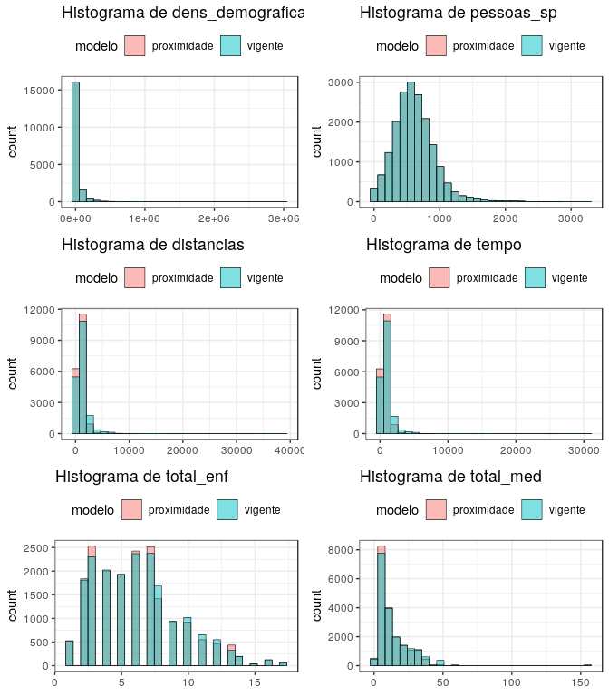

```r
vars <- od %>% select_if(is.numeric) %>% select(-oportunidades) %>% names()
plots <- lapply(vars, function(i) asha_hist(od, i, "modelo"))
do.call(gridExtra::grid.arrange, c(plots, ncol = 2))
```

# 5 Calcular indicadores

## 5.1 Indicadores de acessiblidade espacial

A acessibilidade espacial é uma ferramenta cada vez mais utilizada na área da saúde. Existe um rico debate a respeito de métodos e medidas apropriadas para mensurar e analisar padrões, mas de modo geral, entre as dimensões da acessibilidade aos serviços de saúde (Penchansky and Thomas 1981), a acessibilidade e a disponibilidade podem ser interpretadas como as que têm natureza espacial. A articulação destas dimensões é o que se chama “acessibilidade espacial” e que vem sendo utilizado nos estudos em saúde com abordagem espacial.

A disponibilidade diz respeito à capacidade de oferta e atendimento dos sistemas e envolve uma relação entre oferta e demanda. A acessibilidade compreende as facilidades e impedâncias de mobilidade para acessar equipamentos de saúde e se refere ao custo, usualmente medido em distância ou tempo, para chegar de uma determinada origem a um determinado destino no espaço geográfico.

Principalmente em contextos urbanos e com alta densidade populacional, onde podem existir múltiplos postos de atendimento e micro-regiões com maiores e menores níveis de demanda aos serviços, pode ocorrer sobreposição na oferta de equipamentos e profissionais. Deste modo a distribuição espacial da capacidade de atendimento pode produzir distorções e desigualdades na acessibilidade à saúde. Assim, é preciso observar estas duas dimensões de forma articulada (Guagliardo 2004).

A análise espacial da acessibilidade à saúde articula no território dimensões de disponibilidade e de acessibilidade, retratando um determinado acoplamento entre a infraestrutura de oferta dos sistemas de saúde e a população.

Quando investigou a acessibilidade espacial à atenção primária à saúde nos EUA, Guagliardo (2004) observou que tratava-se de uma paisagem pouco explorada no campo da acessibilidade á saúde. As lacunas de metodologia e conhecimento que o autor identificou eram mais fortes em relação às zonas urbanas, onde em sua opinião não apenas vive a maior parte da população demandante por serviços, como a falta de estudos mais densos a respeito refletia-se em fragilidade metodológica para abordar o problema em grandes metrópoles.

A atenção básica (ou primária) é considerada um nível estratégico dos sistemas de saúde. Envolve custos baixos de produção e entrega e tem um caráter preventivo que permite trabalhar a saúde na ponta, evitando complicações mais graves e minimizando a demanda por serviços de alta complexidade.

No Brasil, o locus da atenção primária à saúde são as Unidades Básicas de Saúde (UBS), que representam os equipamentos de saúde com maior capilaridade no território e servem como principal porta de entrada no Sistema Único de Saúde (SUS). Para capturar os padrões de acessibilidade espacial á atenção básica no município de São Paulo foram utilizados os indicadores de acessibilidade competitiva (AC) e acessibilidade viável (AV).

## 5.2 Acessibilidade competitiva (AC)

O indicador AC é uma medida de fornecimento-população, que são conhecidas na literatura como medidas de oportunidade competitiva. Sua característica é a incorporação não apenas do número de oportunidades disponíveis em cada localidade, mas da perspectiva de que as oportunidades estão em disputa pelo conjunto de usuários. Assim, a acessibilidade competitivia é uma medida de oportunidade cumulativa associada a cada área de abrangência assim definida: seja $\{ A_1, A_2, \dots, A_n \}$ a partição dos setores censitários que corresponde às áreas de abrangência das $n$ UBS’s do município, ou seja, $\bigcup^{n}_{i=1} A_i$ corresponde ao território do município como um todo e $A_i \bigcap A_j = \varnothing, \forall_i \ne j$. Para uma determinada área de abrangência $A_i$, definimos $O_i$ o número de oportunidades encontradas na UBS $i$, e $D_i$ a demanda por atendimento na unidade de saúde $i$.

A demanda é simplesmente a população vivendo nos setores censitários que compõe a área de abrangência e o número de oportunidades é a soma de todos os enfermeiros e médicos da cada UBS. Assim, o indicador AC é informação do setor censitário baseado na relação espacial entre oportunidades (oferta) e demanda de cada UBS.

O cálculo da acessibilidade competiviva pode ser feito facilmente com a função `asha_ac`.

```r
od <- asha_ac(od, pessoas_sp, cnes, modelo, 1000)
glimpse(od)
```

```
#> Observations: 37,906
#> Variables: 12
#> $ cd_geocodi       <chr> "355030801000001", "355030801000001", "355030...
#> $ cnes             <chr> "2752379", "2752344", "2752379", "2752379", "...
#> $ dens_demografica <dbl> 11173.791, 11173.791, 12747.136, 12747.136, 1...
#> $ pessoas_sp       <int> 806, 806, 913, 913, 625, 625, 572, 572, 754, ...
#> $ distancias       <int> 1621, 1108, 1514, 1514, 1277, 1277, 1146, 114...
#> $ tempo            <int> 1236, 898, 1206, 1206, 1006, 1006, 882, 882, ...
#> $ total_enf        <int> 7, 3, 7, 7, 7, 7, 7, 7, 7, 7, 7, 3, 3, 3, 3, ...
#> $ total_med        <int> 30, 9, 30, 30, 30, 30, 30, 30, 30, 30, 30, 9,...
#> $ oportunidades    <int> 37, 12, 37, 37, 37, 37, 37, 37, 37, 37, 37, 1...
#> $ modelo           <chr> "vigente", "proximidade", "vigente", "proximi...
#> $ demanda          <int> 36391, 29961, 36391, 46490, 36391, 46490, 363...
#> $ ac               <dbl> 1.0167349, 0.4005207, 1.0167349, 0.7958701, 1...
```

A função `asha_ac` inclui duas variáveis no dataset, uma com a demanda de cada área de UBS e outra com o indicador de acessibilidade competitiva. Abaixo visualizamos a distribuição das variáveis de disponibilidade.

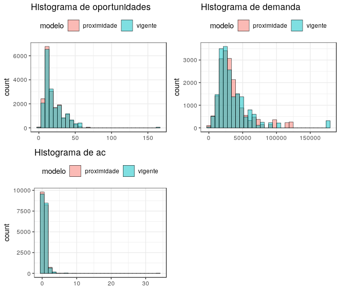

```r
vars <- c("oportunidades", "demanda", "ac")
plots <- lapply(vars, function(i) asha_hist(od, i, fill = "modelo"))
do.call(gridExtra::grid.arrange, c(plots, ncol = 2))
```

## 5.3 Acessibilidade viável (AV)

O Ministério da Saúde do Brasil prioriza o acesso à pé em centros urbanos com alta densidade populacional. De tal maneira definimos 15 minutos como o tempo máximo de caminhada que determina o raio de acessibilidade viável (AV).

Utilizamos o raio AV como parâmetro para calcular a proporção da população em condições adequadas de acessibilidade, que pode ser facilmente criado com a função `asha_av`. Ao indicar o data frame, a coluna de id da área de saúde (zonas de destino) e a variável com o número de habitantes dos setores censitários (zonas de origem), a função adicionará 3 colunas, com os minutos, um variável binária indicando se o setor está no raio de acessibilidade viável ou não e outra que indica a proporção da população no raio de acesso viável em cada UBS.

```r
od <- asha_av(od, cnes, tempo, pessoas_sp, 15)
glimpse(od)
```

```
#> Observations: 37,906
#> Variables: 15
#> $ cd_geocodi       <chr> "355030801000001", "355030801000001", "355030...
#> $ cnes             <chr> "2752379", "2752344", "2752379", "2752379", "...
#> $ dens_demografica <dbl> 11173.791, 11173.791, 12747.136, 12747.136, 1...
#> $ pessoas_sp       <int> 806, 806, 913, 913, 625, 625, 572, 572, 754, ...
#> $ distancias       <int> 1621, 1108, 1514, 1514, 1277, 1277, 1146, 114...
#> $ tempo            <int> 1236, 898, 1206, 1206, 1006, 1006, 882, 882, ...
#> $ total_enf        <int> 7, 3, 7, 7, 7, 7, 7, 7, 7, 7, 7, 3, 3, 3, 3, ...
#> $ total_med        <int> 30, 9, 30, 30, 30, 30, 30, 30, 30, 30, 30, 9,...
#> $ oportunidades    <int> 37, 12, 37, 37, 37, 37, 37, 37, 37, 37, 37, 1...
#> $ modelo           <chr> "vigente", "proximidade", "vigente", "proximi...
#> $ demanda          <int> 36391, 29961, 36391, 46490, 36391, 46490, 363...
#> $ ac               <dbl> 1.0167349, 0.4005207, 1.0167349, 0.7958701, 1...
#> $ minutos          <dbl> 20.600000, 14.966667, 20.100000, 20.100000, 1...
#> $ av               <chr> "Nao", "Sim", "Nao", "Nao", "Nao", "Nao", "Si...
#> $ av_prop          <dbl> 0.5921261, 0.4044983, 0.5921261, 0.5921261, 0...
```

## 5.4 Mesclar variáveis OD em setores_sp

Para concluir a estruturação dos dados incluímos as variáveis geradas no dataset `od` de origem-destino em formato *tidy* na malha de setores censitários. Isto nos permitirá plotar os dados no mapa e analisar os padrões espaciais dos indicadores.

Antes, porém, já criamos algumas variáveis categóricas derivadas dos indicadores.

```r
od <-
  od %>%
  mutate(minutos_classes = cut(minutos,
                               breaks = c(0, 5, 10, 15, 30, 60, Inf),
                               labels = c("< 5", "5 a 10", "10 a 15",
                                          "15 a 30", "30 a 60", "> 60")),
         av_prop_decimais = cut(av_prop,
                                breaks = c(0, .1, .2, .3, .4, .5, .6, .7, .8, .9, 1),
                                labels = c("Até 10%", "10-20%", "20-30%", "30-40%", "40-50%",
                                           "50-60%", "60-70%", "70-80%", "80-90%", "90-100"))) %>%
  group_by(modelo) %>%
  mutate(ac_classes = recode(ntile(ac, 5),
                             "1" = "Q1", "2" = "Q2",
                             "3" = "Q3", "4" = "Q4",
                             "5" = "Q5")) %>%
  ungroup()

vigente <-
  od %>%
  filter(modelo == "vigente") %>%
  select(-pessoas_sp, -dens_demografica, -modelo, -total_enf, -total_med) %>%
  rename(cnes_vig = cnes,
         o_vig = oportunidades, d_vig = demanda,
         ac_vig = ac, minutos_vig = minutos,
         av_vig = av, av_prop_vig = av_prop,
         distancias_vig = distancias, tempo_vig = tempo,
         ac_c_vig = ac_classes, av_prop_decimais_vig = av_prop_decimais,
         minutos_classes_vig = minutos_classes)

proximidade <-
  od %>%
  filter(modelo == "proximidade") %>%
  select(-pessoas_sp, -dens_demografica, -modelo) %>%
  rename(cnes_prox = cnes,
         o_prox = oportunidades, d_prox = demanda,
         ac_prox = ac, minutos_prox = minutos,
         av_prox = av, av_prop_prox = av_prop,
         distancias_prox = distancias, tempo_prox = tempo,
         ac_c_prox = ac_classes, av_prop_decimais_prox = av_prop_decimais,
         minutos_classes_prox = minutos_classes)

setores_sp <-
  setores_sp %>%
  merge(vigente, by = "cd_geocodi", all.x = TRUE) %>%
  merge(proximidade, by = "cd_geocodi", all.x = TRUE)
```

# 6 Analisar indicadores

Com os indicadores criados podemos analisar, por exemplo, a distribuicao espacial das areas dentro do raio de acessibilidade viavel e identificar quais sao as areas prioritarias para a realizacao de medidas visando melhorar a acessibilidade aos serviços de atenção básica. Como temos os dados para dois modelos territoriais diferentes, é possível comparar o desempenho de cada modelo em termos de garantia de acessibilidade viável na cidade.

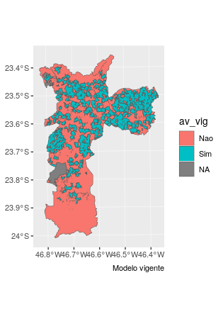

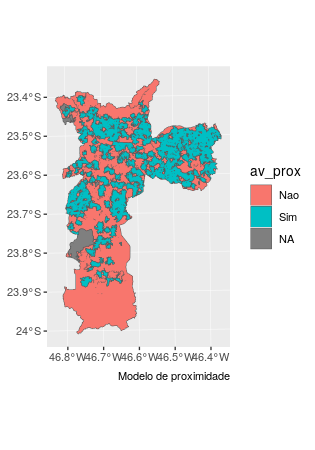

```r
p1 <-
  setores_sp %>%
  group_by(av_vig) %>%
  summarise(pop = sum(pessoas_sp, na.rm = T)) %>%
  ggplot() +
  geom_sf(aes(fill = av_vig), lwd = .2) +
  labs(caption = "Modelo vigente")

p2 <-
  setores_sp %>%
  group_by(av_prox) %>%
  summarise(pop = sum(pessoas_sp, na.rm = T)) %>%
  ggplot() +
  geom_sf(aes(fill = av_prox), lwd = .2) +
  labs(caption = "Modelo de proximidade")

do.call(gridExtra::grid.arrange, c(list(p1, p2), ncol = 2))
```

Podemos ver acima que no modelo de proximidade a área total coberta por condições adequadas de acessibiliade às UBS é mais densa do que no modelo territorial vigente. Mas o que isto significa em termos populacionais? Isto é, qual o percentual de população incluída no raio de AV à atenção básica caso o modelo de proximidade fosse implementado?

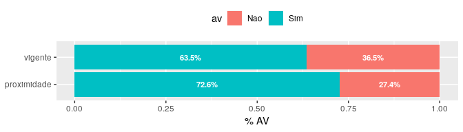

```r
od %>%
  group_by(modelo, av) %>%
  filter(!is.na(av_prop), !is.na(av)) %>%
  summarise(pop = sum(pessoas_sp, na.rm = T)) %>%
  mutate(av_prop = prop.table(pop)) %>%  ggplot(aes(y = av_prop, x = modelo)) +
  geom_bar(aes(fill = av), stat = "identity") +
  geom_text(aes(label = scales::percent(round(av_prop, 3)), group = av),
            position = position_stack(vjust=.5),
            size = 3, color = "white", fontface = "bold") +
  xlab(NULL) + ylab("% AV") +
  theme(legend.position = "top") +
  coord_flip()
```

Teríamos um ganho proporcional de 9%, conforme o gráfico acima. Isto equivaleria ao poder público beneficiar um total estimado de 1.012.815 pessoas com a melhoria da acessibilidade aos postos de atendimento que ofertam serviços de atenção básica de saúde.

O segundo indicador podemos analisar em uma tabela:

```r
od$modelo <- factor(od$modelo, levels=rev(levels(factor(od$modelo))))

df <-
  od %>%
  filter(!is.na(ac_classes)) %>%
  group_by(modelo, ac_classes) %>%
  summarise(AV = median(av_prop, na.rm = TRUE),
            AC = round(median(ac, na.rm = TRUE), 2)) %>%
  rename(Intervalos = ac_classes)

df_tab <-
  df[1:5, 2:4] %>%
  bind_cols(df[6:10, 3:4])

df_tab <- df_tab %>%
  mutate(AV_d = scales::percent(AV1 - AV),
         AV_d = kableExtra::cell_spec(AV_d, color = ifelse(AV_d < 0, "red", "")),
         AC_d = scales::percent((AC1 / AC) - 1),
         AC_d = kableExtra::cell_spec(AC_d, color = ifelse(AC_d < 0, "red", "")),
         AV = scales::percent(AV),
         AV1 = scales::percent(AV1)) %>%
  rename(AC = AC1,
         AV = AV1,
         AC = AC_d,
         AV = AV_d)

knitr::kable(df_tab, escape = F, format = "html", booktabs = T,
      caption = "Medianas dos indicadores: comparação por modelo e quintil de AC",
      format.args = list(decimal.mark = ',', big.mark = ".")) %>%
  kableExtra::kable_styling(font_size = 12) %>%
  kableExtra::add_header_above(c("",
                   "Modelo Vigente" = 2,
                   "Modelo Proximidade" = 2,
                   "Diferenças (Proximidade - Vigente)" = 2))
```

Medianas dos indicadores: comparação por modelo e quintil de AC

| Intervalos | Modelo Vigente AV | Modelo Vigente AC | Modelo Proximidade AV | Modelo Proximidade AC | Diferenças (Proximidade - Vigente) AV | Diferenças (Proximidade - Vigente) AC |
| --- | --- | --- | --- | --- | --- | --- |
| Q1 | 37.7% | 0,26 | 48.1% | 0,22 | 10.5% | -15.4% |
| Q2 | 62.1% | 0,43 | 67.5% | 0,38 | 5.4% | -11.6% |
| Q3 | 78.0% | 0,58 | 81.1% | 0,56 | 3.2% | -3.4% |
| Q4 | 74.3% | 0,74 | 73.7% | 0,77 | -0.6% | 4.1% |
| Q5 | 76.8% | 1,28 | 76.4% | 1,44 | -0.4% | 12.5% |

# Referências

Guagliardo, Mark F. 2004. “Spatial Accessibility of Primary Care: Concepts, Methods and Challenges.” *International Journal of Health Geographics* 3 (1). BioMed Central: 3.

Penchansky, Roy, and J William Thomas. 1981. “The Concept of Access: Definition and Relationship to Consumer Satisfaction.” *Medical Care*. JSTOR, 127–40.

Plummer, Martyn, and Bendix Carstensen. 2011. “Lexis: An R Class for Epidemiological Studies with Long-Term Follow-up.” *Journal of Statistical Software* 38 (5): 1–12. http://www.jstatsoft.org/v38/i05/.

Stevenson, M, T Nunes, J Sanchez, R Thornton, J Reiczigel, J Robison-Cox, P Sebastiani, et al. 2013. “EpiR: An R Package for the Analysis of Epidemiological Data. R Package Version 0.9-48.” *Vienna, Austria: R Foundation for Statistical Computing*.

[^1]: Estudante do curso de Gestão de Políticas Públicas da EACH/USP
[^2]: Professor do curso de Gestão de Políticas Públicas da EACH/USP